# ADZD - GraphFrames

Monika Etrych

```python
from pyspark.sql import DataFrame
from graphframes import graphframe
from pyspark.shell import spark
from graphframes import *
import matplotlib.pyplot as plt
from pyspark.sql.functions import desc, asc, lit, when, col, rand
from pyspark.sql import functions as F
import pandas as pd
import numpy as np
```

### 1

Wczytać graf Facebooka, krawędzie z pliku musae_facebook_edges.csv, atrybuty page_name oraz page_type z pliku musae_facebook_target.csv. Policzyć liczbę krawędzi i wierzchołków. (1 p.)

```python
fb_e = spark.read.csv('facebook_large/musae_facebook_edges.csv', header=True)
fb_t = spark.read.csv('facebook_large/musae_facebook_target.csv', header=True)
fb_e = fb_e.withColumnRenamed('id_1', 'src').withColumnRenamed('id_2', 'dst')
g = GraphFrame(fb_t, fb_e)
```

```python
print('vertices: ', g.vertices.count())
print('edges: ', g.edges.count())
```

```
vertices:  22470
edges:  171002
```

### 2

Sprawdzić czy graf jest spójny. Czy dwa podgrafy utworzone dla typów strony governmental organizations oraz television shows też są spójne? (1 p.)

```python
spark.sparkContext.setCheckpointDir("/tmp/checkpoints")

connected_components = g.connectedComponents()
connected_components.select('component').distinct().show()
```

```
+---------+
|component|
+---------+
|        0|
+---------+
```

Graf składa się z jednego komponentu, nie ma oddzielnych subgrafów.

```python
g_gov= g.filterVertices("page_type = 'government'")
g_tv = g.filterVertices("page_type = 'tvshow'")
g_gov.vertices.toPandas()
```

|  | id | facebook_id | page_name | page_type |
| --- | --- | --- | --- | --- |
| 0 | 1 | 191483281412 | U.S. Consulate General Mumbai | government |
| 1 | 3 | 568700043198473 | Consulate General of Switzerland in Montreal | government |
| 2 | 8 | 544818128942324 | T.C. Mezar-ı Şerif Başkonsolosluğu | government |
| 3 | 9 | 285155655705 | Army ROTC Fighting Saints Battalion | government |
| 4 | 10 | 295294787190810 | NASA Student Launch | government |
| ... | ... | ... | ... | ... |
| 6875 | 22455 | 149100528467930 | Monroe County Sheriff's Office | government |
| 6876 | 22456 | 1770412783239131 | NYPD 33rd Precinct | government |
| 6877 | 22460 | 208741279137778 | US National Weather Service Amarillo Texas | government |
| 6878 | 22463 | 170298223273 | Memphis VA Medical Center | government |
| 6879 | 22467 | 155369444540412 | Ministerio del Interior - Paraguay | government |

6880 rows × 4 columns

```python
print('government')
components_gov = g_gov.connectedComponents()
print(components_gov.select('component').distinct().count())

print('tv_series')
components_tv = g_tv.connectedComponents()
print(components_tv.select('component').distinct().count())
```

```
government
57
tv_series
71
```

Cały graf jest spójny, ale jego podgrafy nie są spójne. Podgrafy składają się z więcej niż jeden komponent.

### 3

Spośród 1000 stron o najwyższym PageRank znaleźć 50 takich (wypisać page_name i page_type), które mają najmniej połączeń oraz 50 o największej liczbie połączeń. Który typ strony był dominujący w każdej z tych kategorii? Narysować wykres zależności PageRank od liczby krawędzi dla wierzchołków (scatter plot) (2 p.)

```python
results = g.pageRank(resetProbability=0.15, tol=0.01)
results.vertices.toPandas()

sorted_results = results.vertices.orderBy(desc("pagerank")).limit(500)
new_graph = GraphFrame(sorted_results, results.edges)

top_20 = sorted_results.select('page_name', 'page_type', 'pagerank').limit(20)
bottom_20 = results.vertices.orderBy(asc("pagerank")).select('page_name', 'page_type', 'pagerank').limit(20)
bottom_20.toPandas()
```

|  | page_name | page_type | pagerank |
| --- | --- | --- | --- |
| 0 | Ponyhof - Die Show | tvshow | 0.376343 |
| 1 | Ministère de l'Enseignement Supérieur, de la R... | government | 0.376343 |
| 2 | Garden Gourmet Deutschland | company | 0.376343 |
| 3 | The Ocean Cleanup | company | 0.376343 |
| 4 | Embassy of Belgium in Norway and Iceland | government | 0.376343 |
| 5 | duplo | company | 0.376343 |
| 6 | USAG Benelux | government | 0.376343 |
| 7 | T.C. Brüksel Büyükelçiliği | government | 0.376343 |
| 8 | Chicago Triathlon | company | 0.376343 |
| 9 | 현대자동차 | company | 0.376343 |
| 10 | Tassimo | company | 0.376343 |
| 11 | Forsvarsdepartementet (Norge) | government | 0.376343 |
| 12 | Disney Interactive Studios Italia | company | 0.376343 |
| 13 | Alfamart | company | 0.376343 |
| 14 | T-Mobile NL | company | 0.376343 |
| 15 | In aller Freundschaft - Die jungen Ärzte | tvshow | 0.376343 |
| 16 | Lindomar Garçon | politician | 0.376343 |
| 17 | Facebook | company | 0.376343 |
| 18 | Progressive Outdoors | company | 0.376343 |
| 19 | Maria Vamvakinou MP | politician | 0.376343 |

```python
print("top 20 pages the most common type is:")
top_20.groupBy("page_type").count().orderBy("count", ascending=False).limit(1).toPandas()
```

```
top 20 pages the most common type is:
```

|  | page_type | count |
| --- | --- | --- |
| 0 | government | 10 |

```python
print("bottom 20 pages the most common type is: ")
bottom_20.groupBy("page_type").count().orderBy("count", ascending=False).limit(1).toPandas()
```

```
bottom 20 pages the most common type is:
```

|  | page_type | count |
| --- | --- | --- |
| 0 | company | 11 |

### Plot

```python
pagerank_degree = results.vertices.join(g.degrees, on='id', how='inner')
pagerank_degree = pagerank_degree.orderBy(desc("pagerank")).select('pagerank', 'degree').toPandas()
```

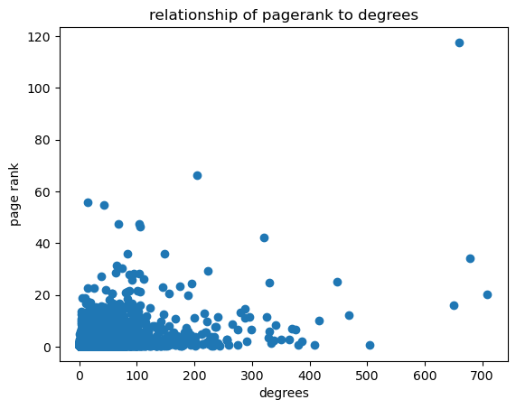

```python
plt.scatter(pagerank_degree['degree'], pagerank_degree['pagerank'])
plt.xlabel('degrees')
plt.ylabel('page rank')
plt.title('relationship of pagerank to degrees')
plt.show()
```

### 4

Korzystając z Pregel API zaimplementować następujący algorytm. W pierwszym kroku wybrana strona publikuje post fake news. W kolejnym kroku ten post publikowany jest przez 1/4 losowo wybranych kontaktów tej strony. W dalszych krokach, dla każdej strony, która opublikowała już ten post, losowo wybrane 1/4 jej kontaktów publikuje go u siebie. Pokazać jak zmienia się liczba stron które opublikowały post w zależności od liczby kroków. (2 p.) Opcjonalnie: Sprawdzić powyższą zależność dla współczynnika innego niż 1/4.

```python
from graphframes.lib import Pregel
fb_e = spark.read.csv('facebook_large/musae_facebook_edges.csv', header=True)
fb_t = spark.read.csv('facebook_large/musae_facebook_target.csv', header=True)
fb_e = fb_e.withColumnRenamed('id_1', 'src').withColumnRenamed('id_2', 'dst')
graph = GraphFrame(fb_t, fb_e)
```

### First post

```python
def send_fake(graph, steps, spread_factor, start_node):
    # init post
    g = graph
    is_post = g.vertices.withColumn("is_post", lit(0))
    g = GraphFrame(is_post, g.edges)

    new_pages = []
    start_page_id = str(start_node)
    df_spark = g.vertices
    first_post = df_spark.withColumn('is_post',
                                   F.when(df_spark['id'] == start_page_id, 1)
                                    .otherwise(df_spark['is_post']))
    print(f"Step 0: 1 pages published")
    new_pages.append(1)
    g = GraphFrame(first_post, g.edges)

    for step in range(steps):
        # send massage to neighbours
        messages = g.edges.join(g.vertices, g.edges.src == g.vertices.id) \
            .where(col("is_post") == 1) \
            .withColumn("spread", (rand() < spread_factor).cast("int")) \
            .select(col("dst").alias("id"), "spread")

        # update status "is_post" based on massages
        updated = messages.groupBy("id").agg({"spread": "max"}) \
            .withColumnRenamed("max(spread)", "spread") \
            .join(g.vertices, "id", "right_outer") \
            .fillna(0, ["spread"]) \
            .withColumn("is_post", when((col("is_post") == 1) | (col("spread") == 1), 1).otherwise(0)) \
            .select("id", "facebook_id", "page_name", "page_type", "is_post")

        g = GraphFrame(updated, g.edges)

        # # number of posted sites
        count_published = g.vertices.filter(col("is_post") == 1).count() - sum(new_pages)
        new_pages.append(count_published)
        print(f"Step {step + 1}: {count_published} pages published")
    return new_pages
```

```python
def plot_pages_steps(graph, steps=5, spread_factor=0.25, start_node=1):
    pages = send_fake(graph, steps=steps, spread_factor=spread_factor, start_node=start_node)
    plt.scatter(x=list(range(1, len(pages) + 1)) , y=pages)
    plt.xlabel('steps')
    plt.ylabel('posted pages')
    plt.title(f'relationship of posted pages to steps for starting node {start_node} and spread factor={spread_factor}')
    plt.show()
```

```
Step 0: 1 pages published
Step 1: 4 pages published
Step 2: 29 pages published
Step 3: 171 pages published
Step 4: 404 pages published
Step 5: 613 pages published
```

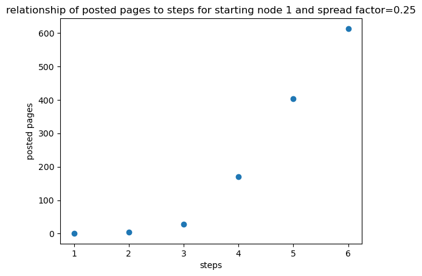

```python
plot_pages_steps(graph, steps=5, spread_factor=0.25, start_node=1)
```

```
Step 0: 1 pages published
Step 1: 1 pages published
Step 2: 2 pages published
Step 3: 1 pages published
Step 4: 1 pages published
Step 5: 1 pages published
Step 6: 0 pages published
Step 7: 0 pages published
Step 8: 0 pages published
Step 9: 0 pages published
Step 10: 0 pages published
```

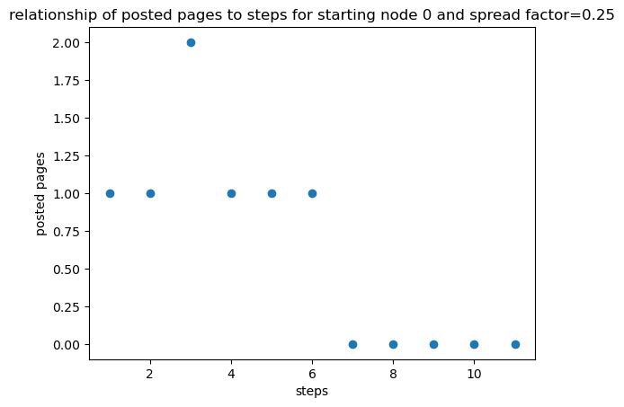

```python
from pyspark import SparkConf
from pyspark.sql import SparkSession
conf = SparkConf().set("spark.executor.memory", "4g") \
                  .set("spark.driver.memory", "4g") \
                  .set("spark.executor.extraJavaOptions", "-XX:+UseG1GC")
spark = SparkSession.builder.config(conf=conf).getOrCreate()
plot_pages_steps(graph, steps=10, spread_factor=0.25, start_node=0)
```

```
Step 0: 1 pages published
Step 1: 26 pages published
Step 2: 313 pages published
Step 3: 1072 pages published
Step 4: 1975 pages published
Step 5: 1913 pages published
Step 6: 1295 pages published
Step 7: 764 pages published
Step 8: 510 pages published
Step 9: 323 pages published
Step 10: 181 pages published
```

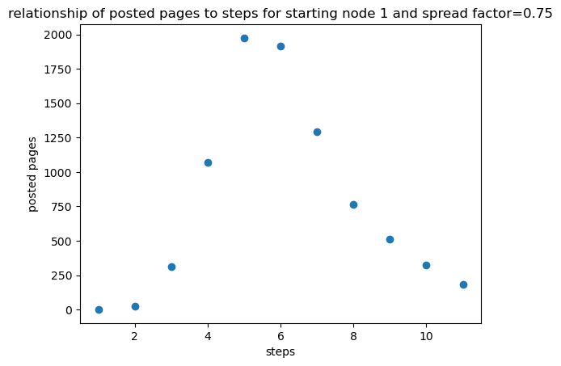

```python
plot_pages_steps(graph, steps=10, spread_factor=0.75, start_node=1)
```

```
Step 0: 1 pages published
Step 1: 2 pages published
Step 2: 5 pages published
Step 3: 16 pages published
Step 4: 52 pages published
Step 5: 109 pages published
Step 6: 171 pages published
Step 7: 249 pages published
Step 8: 274 pages published
Step 9: 292 pages published
Step 10: 320 pages published
```

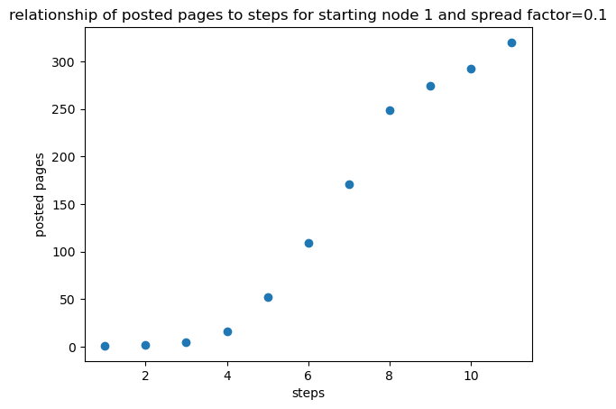

```python
plot_pages_steps(graph, steps=10, spread_factor=0.1, start_node=1)
```

### 5

Narysować wykres rozkładu stopnia wierzchołków w grafie w skali logarytmicznej. Można skorzystać z metody stat.approxQuantile. Czy sieć jest bezskalowa (scale-free)? https://barabasi.com/f/623.pdf (2 p.)

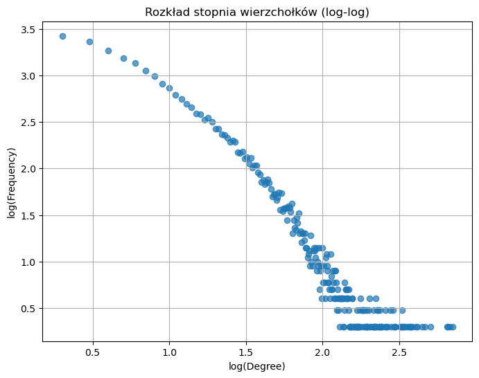

```
Sieć prawdopodobnie jest bezskalowa.
```

```python
degrees = graph.degrees

# Use approxQuantile to create ranges
quantiles = degrees.select("degree").stat.approxQuantile("degree", probabilities=[0.25, 0.5, 0.75], relativeError=0.01)

degree_distribution = degrees.groupBy("degree").count().orderBy("degree").toPandas()

plt.figure(figsize=(8, 6))
plt.scatter(
    np.log10(degree_distribution["degree"] + 1),
    np.log10(degree_distribution["count"] + 1),
    alpha=0.7
)
plt.title("Rozkład stopnia wierzchołków (log-log)")
plt.xlabel("log(Degree)")
plt.ylabel("log(Frequency)")
plt.grid(True)
plt.show()

# scale-free
degree_values = degree_distribution["degree"].values
frequency_values = degree_distribution["count"].values

if len(degree_values) > 0 and np.max(degree_values) / np.min(degree_values) > 100:
    print("Sieć prawdopodobnie jest bezskalowa.")
else:
    print("Sieć prawdopodobnie nie jest bezskalowa.")
```

Sieć bezskalowa, to taka w której większość wierzchołków ma niewiele połączeń.